# Homework6 - Hearing Customer voices

### Notice:

1. Mechanical correctness of your python codes: your codes must be accurate and no errors
2. Clarity of jupyter notebook and organization of outputs:
- The python codes you write must be accompanied with "comments" using # or markdown if necessary
- All outputs must be visible in your jupyter notebook. If necessary, explain the outputs using markdown.
- A **grade of XF** can result from a breach of academic honesty. The F indicates failure in the course; the X indicates the reason is an Honor Pledge violation.” (http://www.k-state.edu/provost/resources/teaching/course.htm (Links to an external site.)) (See Academic Dishonesty below).
- **Unauthorized collaboration** (including but not limited to collaborating with other students on lab, HW, the midterm exam, and the final project is forbidden)
- **Unauthorized aid** (including but not limited to sharing your codes with other students, receiving codes from another)
- Plagiarism (including but not limited to copying words of another (on the Internet or articles) as your own)

**K-State Honor Code**

> **"On my honor, as a student, I have neither given nor received unauthorized aid on this academic work."**

**Your Name:** Saloni Prakash

```python
# run the following syntax and sign with your full name
input("Please sign the E-Signature (full name):")
```

```
'Saloni Prakash'
```

# Homework 6: Hearing customers’ voices II

This homework covers week 13. Please download `7_products_reviews.csv` and finish the following 5 questions. The total points of this homework are 70.

### Pre-processing data

- Import the data
- Filter the nouns and adjectives
- Get the product ID

```python
# Importing the data
import pandas as pd

reviews = pd.read_csv("7_products_reviews.csv")
reviews
```

|  | Product_url | Customer | Ratings | Date | Review_text | Location |
| --- | --- | --- | --- | --- | --- | --- |
| 0 | https://www.amazon.com/product-reviews/B00004O... | leek | 5 | 2025-09-13 00:00:00 | My old OXO salad spinner bit the dust after ma... | United States |
| 1 | https://www.amazon.com/product-reviews/B00004O... | CareChris | 5 | 2025-07-21 00:00:00 | This is my second OXO salad spinner. I was giv... | United States |
| 2 | https://www.amazon.com/product-reviews/B00004O... | Amazon Customer | 5 | 2025-09-10 00:00:00 | such an improvement over original model the ... | United States |
| 3 | https://www.amazon.com/product-reviews/B00004O... | Catman2 | 5 | 2025-09-14 00:00:00 | We had a very old OXO spinner that was quite g... | United States |
| 4 | https://www.amazon.com/product-reviews/B00004O... | Marksman | 5 | 2025-09-12 00:00:00 | Best design because you easily separate the to... | United States |
| ... | ... | ... | ... | ... | ... | ... |
| 625 | https://www.amazon.com/product-reviews/B001T6J... | Ann G | 4 | 2024-11-02 00:00:00 | I am not a professional baker but I really lo... | United States |
| 626 | https://www.amazon.com/product-reviews/B001T6J... | Michael | 4 | 2023-08-14 00:00:00 | This parchment paper is highly rated for it qu... | United States |
| 627 | https://www.amazon.com/product-reviews/B001T6J... | tooblonde | 4 | 2024-07-02 00:00:00 | Great paper that we use daily for sheet pan co... | United States |
| 628 | https://www.amazon.com/product-reviews/B001T6J... | Amazon Customer | 4 | 2024-09-02 00:00:00 | I love this parchment paper. Nothing strange ... | United States |
| 629 | https://www.amazon.com/product-reviews/B001T6J... | Mary B | 5 | 2024-10-23 00:00:00 | This parchment paper is the perfect addition t... | United States |

630 rows × 6 columns

```python
# Filtering the nouns and adjectives and Getting the product ID

import re
import nltk
from nltk.tokenize import word_tokenize
from nltk.corpus import stopwords
from nltk.stem import WordNetLemmatizer
from nltk.tag import pos_tag


# Extract product ID from product URL
def extract_product_id(url):
    """
    Amazon review URLs look like:
    https://www.amazon.com/product-reviews/B00004O...
    Product ID starts with 'B' and is 10 characters long.
    """
    match = re.search(r"/([A-Z0-9]{10})(?=[/?])", url)
    if match:
        return match.group(1)
    return None


# Filter only nouns + adjectives ---
lemmatizer = WordNetLemmatizer()

def clean_nouns_adjectives(text):

    # Lowercase
    text = text.lower()

    # Remove special characters
    text = re.sub(r"[^a-zA-Z0-9\s]", " ", text)

    # Tokenize
    tokens = word_tokenize(text)

    # Remove stopwords
    stop_words = set(stopwords.words("english"))
    filtered_tokens = [w for w in tokens if w not in stop_words]

    # POS tagging
    tagged_words = pos_tag(filtered_tokens)

    # Extract nouns & adjectives
    nouns = [lemmatizer.lemmatize(w, "n") for w, t in tagged_words if t.startswith("NN")]
    adjs  = [lemmatizer.lemmatize(w, "a") for w, t in tagged_words if t.startswith("JJ")]

    # Combine nouns + adjectives
    combined = nouns + adjs

    # Return as single string
    return " ".join(combined)
```

```python
reviews["Product_ID"] = reviews["Product_url"].apply(extract_product_id)
reviews["Nouns_adjs"] = reviews["Review_text"].apply(clean_nouns_adjectives)
```

```python
reviews
```

|  | Product_url | Customer | Ratings | Date | Review_text | Location | Product_ID | Nouns_adjs |
| --- | --- | --- | --- | --- | --- | --- | --- | --- |
| 0 | https://www.amazon.com/product-reviews/B00004O... | leek | 5 | 2025-09-13 00:00:00 | My old OXO salad spinner bit the dust after ma... | United States | B00004OCKR | oxo salad spinner bit year drop time use thing... |
| 1 | https://www.amazon.com/product-reviews/B00004O... | CareChris | 5 | 2025-07-21 00:00:00 | This is my second OXO salad spinner. I was giv... | United States | B00004OCKR | oxo salad spinner year thing year brand spinne... |
| 2 | https://www.amazon.com/product-reviews/B00004O... | Amazon Customer | 5 | 2025-09-10 00:00:00 | such an improvement over original model the ... | United States | B00004OCKR | improvement model bowl thick basket thicker st... |
| 3 | https://www.amazon.com/product-reviews/B00004O... | Catman2 | 5 | 2025-09-14 00:00:00 | We had a very old OXO spinner that was quite g... | United States | B00004OCKR | oxo spinner spinner way spinner use job old go... |
| 4 | https://www.amazon.com/product-reviews/B00004O... | Marksman | 5 | 2025-09-12 00:00:00 | Best design because you easily separate the to... | United States | B00004OCKR | design spinner spinner spin lettuce moldy spin... |
| ... | ... | ... | ... | ... | ... | ... | ... | ... |
| 625 | https://www.amazon.com/product-reviews/B001T6J... | Ann G | 4 | 2024-11-02 00:00:00 | I am not a professional baker but I really lo... | United States | B001T6JTMY | baker parchment stop food baking pan professional |
| 626 | https://www.amazon.com/product-reviews/B001T6J... | Michael | 4 | 2023-08-14 00:00:00 | This parchment paper is highly rated for it qu... | United States | B001T6JTMY | paper quality purity product edge box action r... |
| 627 | https://www.amazon.com/product-reviews/B001T6J... | tooblonde | 4 | 2024-07-02 00:00:00 | Great paper that we use daily for sheet pan co... | United States | B001T6JTMY | paper use sheet pan cooking bread dutch paper ... |
| 628 | https://www.amazon.com/product-reviews/B001T6J... | Amazon Customer | 4 | 2024-09-02 00:00:00 | I love this parchment paper. Nothing strange ... | United States | B001T6JTMY | paper nothing complaint edge product parchment... |
| 629 | https://www.amazon.com/product-reviews/B001T6J... | Mary B | 5 | 2024-10-23 00:00:00 | This parchment paper is the perfect addition t... | United States | B001T6JTMY | paper addition everything cooky pretzel peace ... |

630 rows × 8 columns

```python
# check the products' IDs

reviews["Product_ID"].unique()
```

```
array(['B00004OCKR', 'B003OAJGJO', 'B00FLYWNYQ', 'B00006JSUA',
       'B007WQ9YNO', 'B0026RHI3M', 'B001T6JTMY'], dtype=object)
```

**Q1: Use the `Gensim LDA` model to calculate coherence scores for a range of topics from 2 to 10, and determine the optimal number of topics for the entire corpus (`reviews["Nouns_adjs"]`).** (4 points)

- Calculate the coherence score using the "c_v" method.

```python
from gensim.corpora import Dictionary
from gensim.models import LdaModel, CoherenceModel
from nltk.tokenize import word_tokenize
```

```python
from gensim.corpora import Dictionary
from gensim.models import LdaModel, CoherenceModel
from nltk.tokenize import word_tokenize

# Tokenize the cleaned text column
token_list = reviews["Nouns_adjs"].dropna().apply(lambda x: word_tokenize(x))

# Create a dictionary and corpus for LDA
dictionary = Dictionary(token_list)
corpus = [dictionary.doc2bow(text) for text in token_list]

coherence_scores = []

# Train LDA models for topics 2–10
for k in range(2, 11):
    lda_model = LdaModel(
        corpus=corpus,
        id2word=dictionary,
        num_topics=k,
        random_state=0,   # fixing random state for reproducibility
        passes=10,        # number of passes through the corpus
        iterations=100    # number of iterations per pass
    )

    # Calculate coherence score using c_v method
    coherence_model = CoherenceModel(
        model=lda_model,
        texts=token_list,
        dictionary=dictionary,
        coherence='c_v'
    )

    coherence = coherence_model.get_coherence()
    coherence_scores.append((k, coherence))
    print(f"Topics={k}, Coherence={coherence}")

# Select the number of topics with highest coherence
best_k = max(coherence_scores, key=lambda x: x[1])[0]
print("\nOptimal number of topics:", best_k)
```

```
Topics=2, Coherence=0.23367805018857513
Topics=3, Coherence=0.27334587994942744
Topics=4, Coherence=0.25419284783549095
Topics=5, Coherence=0.2753685371367123
Topics=6, Coherence=0.2852850117586468
Topics=7, Coherence=0.28889627314990285
Topics=8, Coherence=0.28306893961658675
Topics=9, Coherence=0.31381164248734494
Topics=10, Coherence=0.28899261503233176

Optimal number of topics: 9
```

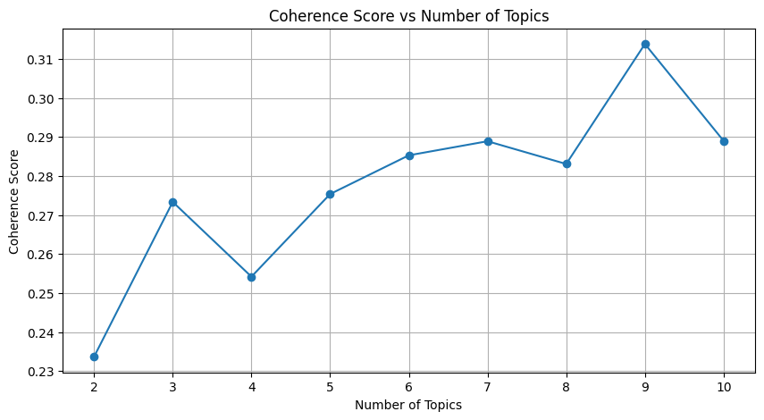

```python
import matplotlib.pyplot as plt

# Separate topic numbers and coherence values
topics = [k for k, c in coherence_scores]
scores = [c for k, c in coherence_scores]

# Plot
plt.figure(figsize=(10, 5))
plt.plot(topics, scores, marker='o')
plt.title("Coherence Score vs Number of Topics")
plt.xlabel("Number of Topics")
plt.ylabel("Coherence Score")
plt.xticks(topics)
plt.grid(True)
plt.show()
```

**Q2a: Separate the reviews by product, build the `sklearn LDA` model for each one using two vectorizers (TfidfVectorizer and CountVectorizer, set the parameter stop_words="english" if you didn't remove the stopwords in the clean_pipeline), and apply the optimal k from Q1.** (14 points)

```python
from sklearn.feature_extraction.text import TfidfVectorizer, CountVectorizer
from sklearn.decomposition import LatentDirichletAllocation

best_k = 9  # from Q1

# Group by product
products = reviews["Product_ID"].unique()

lda_results = {}

for pid in products:
    product_reviews = reviews[reviews["Product_ID"] == pid]["Nouns_adjs"].dropna()

    # TF-IDF vectorizer
    tfidf_vectorizer = TfidfVectorizer(stop_words='english')
    tfidf_matrix = tfidf_vectorizer.fit_transform(product_reviews)

    lda_tfidf = LatentDirichletAllocation(n_components=best_k, random_state=0)
    lda_tfidf.fit(tfidf_matrix)

    # Count vectorizer
    count_vectorizer = CountVectorizer(stop_words='english')
    count_matrix = count_vectorizer.fit_transform(product_reviews)

    lda_count = LatentDirichletAllocation(n_components=best_k, random_state=0)
    lda_count.fit(count_matrix)

    # Store results
    lda_results[pid] = {"TFIDF": lda_tfidf, "Count": lda_count}
```

```python
# use a for loop for feature engineering

# Number of top words per topic
top_n = 10

for pid in reviews["Product_ID"].unique():
    print(f"\nTop {best_k} topics (LDA) for reviews of {pid} using TF-IDF Vectorizer:")
    lda_tfidf = lda_results[pid]["TFIDF"]
    tfidf_vectorizer = TfidfVectorizer(stop_words='english')
    tfidf_matrix = tfidf_vectorizer.fit_transform(
        reviews.loc[reviews["Product_ID"] == pid, "Nouns_adjs"].dropna()
    )
    feature_names = tfidf_vectorizer.get_feature_names_out()

    for topic_idx, topic in enumerate(lda_tfidf.components_):
        top_words = [feature_names[i] for i in topic.argsort()[-top_n:][::-1]]
        print(f"Topic {topic_idx}: {', '.join(top_words)}")

    print(f"\nTop {best_k} topics (LDA) for reviews of {pid} using Count Vectorizer:")
    lda_count = lda_results[pid]["Count"]
    count_vectorizer = CountVectorizer(stop_words='english')
    count_matrix = count_vectorizer.fit_transform(
        reviews.loc[reviews["Product_ID"] == pid, "Nouns_adjs"].dropna()
    )
    feature_names = count_vectorizer.get_feature_names_out()

    for topic_idx, topic in enumerate(lda_count.components_):
        top_words = [feature_names[i] for i in topic.argsort()[-top_n:][::-1]]
        print(f"Topic {topic_idx}: {', '.join(top_words)}")
```

```
Top 9 topics (LDA) for reviews of B00004OCKR using TF-IDF Vectorizer:
Topic 0: lettuce, spinner, lot, grape, green, super, useful, bowl, big, salad
Topic 1: great, easy, use, job, veggie, lv, wow, clean, spin, collapse
Topic 2: work, good, product, brand, fast, salad, imbalance, familiar, center, satisfied
Topic 3: year, price, husband, spinner, fine, dry, use, good, salad, vegetable
Topic 4: big, great, product, nice, efficient, bit, salad, small, little, piece
Topic 5: towel, bowl, purchasei, wonder, improvement, daughter, plastic, make, berry, paper
Topic 6: spinner, year, salad, son, pleased, apartment, model, romaine, best, wash
Topic 7: large, salad, person, size, old, spinner, great, soak, quality, durable
Topic 8: easy, use, work, lettuce, love, second, salad, spinner, good, great

Top 9 topics (LDA) for reviews of B00004OCKR using Count Vectorizer:
Topic 0: spinner, easy, bowl, lettuce, year, salad, dishwasher, work, great, old
Topic 1: product, use, clean, easy, great, green, pick, veggie, glass, job
Topic 2: spinner, salad, good, use, plastic, clean, fast, easy, lettuce, dry
Topic 3: salad, spinner, large, size, bowl, old, perfect, person, small, year
Topic 4: big, spinner, salad, great, product, fruit, small, vegetable, spin, piece
Topic 5: dry, spinner, salad, water, spin, lid, towel, bowl, time, long
Topic 6: spinner, year, salad, work, easy, oxo, use, nice, model, best
Topic 7: large, spinner, salad, use, easy, daughter, soak, purchase, house, romaine
Topic 8: salad, lettuce, use, great, water, spinner, easy, lot, wash, second

Top 9 topics (LDA) for reviews of B003OAJGJO using TF-IDF Vectorizer:
Topic 0: heavy, great, food, disappointed, seller, guy, season, snap, cook, item
Topic 1: cooker, slow, fit, bean, liner, hot, delicious, size, bomb, diggity
Topic 2: great, large, replacement, beautiful, crockpot, investment, size, sure, chocolate, wash
Topic 3: figure, use, time, little, pot, new, work, end, seal, bad
Topic 4: crockpot, hot, work, fine, day, slow, turn, indicator, chili, cooker
Topic 5: good, slow, cooker, big, recipe, family, machine, event, crockpot, forget
Topic 6: awesome, crockpot, product, great, new, calphalon, cool, thing, hour, slow
Topic 7: work, gift, easy, cleaning, home, heat, nice, want, timer, store
Topic 8: pot, crock, meal, size, great, small, use, work, unit, low

Top 9 topics (LDA) for reviews of B003OAJGJO using Count Vectorizer:
Topic 0: pot, roast, time, cooking, heavy, delicious, food, great, money, meal
Topic 1: cooker, cook, slow, bean, pot, work, large, hot, meat, temp
Topic 2: pot, large, easy, great, crock, chocolate, warm, food, clean, high
Topic 3: pot, crock, old, hot, new, lid, cooker, food, handle, time
Topic 4: crockpot, good, day, size, hot, cook, hour, veggie, low, potato
Topic 5: slow, cooker, pot, quart, crock, low, hot, unit, capacity, touch
```

[output cut: 98 more lines]

```
Topic 5: ok, work, paper, great, good, store, parchment, toxic, non, food
Topic 6: quality, use, sheet, box, paper, edge, parchment, good, sharp, buy
Topic 7: use, huh, sure, great, safe, work, family, local, paper, box
Topic 8: paper, wish, great, box, foil, parchment, time, aluminum, product, teeth

Top 9 topics (LDA) for reviews of B001T6JTMY using Count Vectorizer:
Topic 0: pan, baking, food, stop, baker, professional, parchment, love, great, suck
Topic 1: paper, box, use, great, time, cutter, cut, edge, scissors, product
Topic 2: paper, parchment, use, transfer, product, press, good, sharp, bake, box
Topic 3: paper, parchment, good, work, cutter, quality, excellent, product, cut, roll
Topic 4: paper, parchment, product, tbsp, chia, cracker, tsp, sheet, great, egg
Topic 5: paper, parchment, good, toxic, great, food, chemical, family, non, store
Topic 6: use, sheet, non, foil, aluminum, excellent, stick, value, awesome, plastic
Topic 7: paper, parchment, use, time, biscuit, sheet, cookie, good, local, unbleached
Topic 8: box, product, end, parchment, year, star, great, need, free, item
```

**Q2b: Summerize the topic theme based on the LDA topic keywords for each product. Explain your findings.** (5 points)

B00004OCKR: Reviews highlight ease of use, cleaning, and bowl size for salads, with minor issues like imbalance. B003OAJGJO: Slow cooking, consistent meal results, and durability are emphasized, along with suitable size for families. B00FLYWNYQ: Instant Pot reviews focus on convenience, pressure cooking, and efficiency for meal preparation. B00006JSUA: Cast iron pan users praise versatility, material quality, and ease of cleaning. B007WQ9YNO: Rice cooker reviews mention accurate measurements, simple operation, and reliable cooking results. B0026RHI3M: Nonstick cookie sheets are appreciated for durability, performance, and ease of cleaning, with occasional rust noted. B001T6JTMY: Parchment paper reviews highlight usability, quality, and safety for baking. Overall, themes across products include ease of use, durability, and value for money. TF-IDF and count vectorizers capture slightly different keywords but yield similar interpretations. Topic modeling effectively summarizes customer feedback, revealing main product strengths and minor concerns.

**Q3a: Separate the reviews by product, build the `sklearn NMF` model for each one using two vectorizers (TfidfVectorizer and CountVectorizer, set the parameter stop_words="english" if you didn't remove the stopwords in the clean_pipeline), and apply the optimal k from Q1.** (14 points)

```python
from sklearn.feature_extraction.text import TfidfVectorizer, CountVectorizer
from sklearn.decomposition import NMF

best_k = 9  # from Q1

products = reviews["Product_ID"].unique()
nmf_results = {}

for pid in products:
    product_reviews = reviews[reviews["Product_ID"] == pid]["Nouns_adjs"].dropna()

    # TF-IDF
    tfidf_vectorizer = TfidfVectorizer(stop_words='english')
    tfidf_matrix = tfidf_vectorizer.fit_transform(product_reviews)
    nmf_tfidf = NMF(n_components=best_k, random_state=0)
    nmf_tfidf.fit(tfidf_matrix)

    # Count
    count_vectorizer = CountVectorizer(stop_words='english')
    count_matrix = count_vectorizer.fit_transform(product_reviews)
    nmf_count = NMF(n_components=best_k, random_state=0)
    nmf_count.fit(count_matrix)

    # Store results
    nmf_results[pid] = {"TFIDF": (nmf_tfidf, tfidf_vectorizer),
                        "Count": (nmf_count, count_vectorizer)}
```

```python
# use a for loop for feature engineering


top_n = 10  # top words per topic

for pid in reviews["Product_ID"].unique():
    print(f"\nTop {best_k} topics (NMF) for reviews of {pid} using TF-IDF Vectorizer:")
    nmf_tfidf, tfidf_vectorizer = nmf_results[pid]["TFIDF"]
    feature_names = tfidf_vectorizer.get_feature_names_out()

    for topic_idx, topic in enumerate(nmf_tfidf.components_):
        top_words = [feature_names[i] for i in topic.argsort()[-top_n:][::-1]]
        print(f"Topic {topic_idx}: {', '.join(top_words)}")

    print(f"\nTop {best_k} topics (NMF) for reviews of {pid} using Count Vectorizer:")
    nmf_count, count_vectorizer = nmf_results[pid]["Count"]
    feature_names = count_vectorizer.get_feature_names_out()

    for topic_idx, topic in enumerate(nmf_count.components_):
        top_words = [feature_names[i] for i in topic.argsort()[-top_n:][::-1]]
        print(f"Topic {topic_idx}: {', '.join(top_words)}")
```

```
Top 9 topics (NMF) for reviews of B00004OCKR using TF-IDF Vectorizer:
Topic 0: salad, spinner, best, old, pleased, oxo, fast, cleaning, brand, design
Topic 1: work, store, good, nice, size, son, model, apartment, romaine, great
Topic 2: easy, use, second, love, dry, clean, good, vegetable, quality, sturdy
Topic 3: fine, year, price, good, spinner, people, apartment, son, model, small
Topic 4: great, job, quality, durable, husband, grape, lv, wow, month, efficient
Topic 5: big, lettuce, lot, super, bit, glad, spin, small, little, size
Topic 6: product, pick, imbalance, satisfied, center, edge, familiar, plunger, clean, brand
Topic 7: large, person, perfect, size, unit, household, happy, old, salad, version
Topic 8: bowl, nice, glass, heavy, dishwasher, dish, mechanism, plastic, serve, beautiful

Top 9 topics (NMF) for reviews of B00004OCKR using Count Vectorizer:
Topic 0: spinner, salad, old, good, best, fast, design, pump, lettuce, crank
Topic 1: dry, lid, spinner, lettuce, spin, year, oxo, salad, bowl, brand
Topic 2: water, spin, long, time, basket, bit, bad, way, small, good
Topic 3: large, spin, bowl, old, inner, small, crank, spinner, lid, press
Topic 4: salad, plastic, size, product, use, quality, perfect, day, lot, great
Topic 5: easy, use, clean, green, sturdy, dry, store, veggie, good, time
Topic 6: big, small, spinner, glad, lettuce, bought, wash, vegetable, piece, refrigerator
Topic 7: salad, love, spinner, dish, bowl, kitchen, green, glass, storage, lid
Topic 8: bowl, year, dishwasher, safe, great, product, mechanism, clean, low, rack

Top 9 topics (NMF) for reviews of B003OAJGJO using TF-IDF Vectorizer:
Topic 0: use, perfect, easy, size, time, simple, guy, single, food, family
Topic 1: work, figure, charm, meal, love, day, pleased, easy, cleanup, snap
Topic 2: great, price, seller, replacement, item, value, sure, awesome, changer, game
Topic 3: pot, crock, old, price, roast, new, lid, cook, sure, large
Topic 4: cooker, slow, quart, capacity, hour, fantastic, forget, bomb, diggity, tasty
Topic 5: good, machine, day, event, snap, value, wish, seal, size, family
Topic 6: crockpot, hot, touch, recipe, fine, awesome, cook, case, heat, thing
Topic 7: meal, love, capacity, quart, family, manual, day, oval, cook, kitchen
Topic 8: small, nice, big, family, size, unit, large, crock, home, beautiful

Top 9 topics (NMF) for reviews of B003OAJGJO using Count Vectorizer:
Topic 0: pot, crock, calphalon, maximatic, slow, cooker, hot, big, day, touch
Topic 1: slow, quart, cooker, capacity, stoneware, review, pot, material, water, lip
Topic 2: unit, low, hour, sorta, day, good, crockpot, hot, home, light
Topic 3: pot, crock, cooker, hot, old, time, steam, comment, handle, outside
Topic 4: meal, slow, easy, family, cooker, quart, manual, pot, kitchen, oval
Topic 5: old, food, lid, bc, pot, unit, family, edge, cook, handle
```

[output cut: 98 more lines]

```
Topic 5: biscuit, sheet, cookie, time, baking, non, stick, difficult, driver, bakery
Topic 6: excellent, product, oven, tray, nice, degree, veggie, performs, thanks, need
Topic 7: buy, unbleached, food, store, cheap, kitchen, toxic, quality, time, pan
Topic 8: work, quality, bit, narrow, ok, huh, roll, read, dimension, small

Top 9 topics (NMF) for reviews of B001T6JTMY using Count Vectorizer:
Topic 0: paper, parchment, use, food, foil, family, price, quality, store, cutter
Topic 1: tbsp, tsp, chia, cracker, parchment, sticky, salt, italian, egg, seed
Topic 2: transfer, press, parchment, use, sheet, second, finish, teflon, dtf, great
Topic 3: box, cutter, cut, paper, time, hand, crush, end, need, scissors
Topic 4: paper, sharp, product, edge, use, scissors, box, fine, quality, manufacturer
Topic 5: edge, use, bad, company, time, product, charge, department, useless, paper
Topic 6: biscuit, sheet, time, cookie, parchment, paper, non, stick, long, baking
Topic 7: product, good, work, excellent, silicone, sheet, clean, quality, friendly, great
Topic 8: paper, great, tear, box, use, sheet, edge, pan, daily, bread
```

**Q3b:Summerize the topic theme based on the NMF topic keywords for each product. Explain your findings.** (5 points)

For all products, NMF topics capture product type, usability, performance, and quality, similar to LDA. For B00004OCKR, both NMF and LDA highlight salad spinner use, cleaning, and durability, though NMF emphasizes specific parts like lids and bowls. For cooking appliances like B003OAJGJO and B00FLYWNYQ, both methods identify size, cooking performance, and ease of use, but NMF provides more practical details about appliance components. For cookware (B00006JSUA, B0026RHI3M) and parchment paper (B001T6JTMY), NMF focuses on material, maintenance, and functionality, while LDA leaned slightly more on general satisfaction and sentiment. Overall, NMF gives a more structured view of product features and usage, whereas LDA captured broader themes and customer experiences.